# The Effects of Marijuana Legalization on Crime and Other Drug Usage in Seattle

Benjamin Gaiser and Jeremy Russell

16 December 2016

## Literature Review and Policy Relevance (ca. 1200 words)

In 2012, Colorado and Washington legalized recreational marijuana use, and in 2014 Oregon and Alaska followed suit. In November 2016, five other states (Arizona, California, Maine, Massachusetts and Nevada) voted on legalizing the recreational use of marijuana, while four others (Arkansas, Florida, Montana and North Dakota) also decide on medical marijuana initiatives. Opponents of legalization claim legalization leads to an increase in marijuana and other drug use, “increases crime, diminishes traffic safety, harms public health, and lowers teen educational achievement,” while advocates “think legalization reduces crime, raises tax revenue, lowers criminal justice expenditures, improves public health, bolsters traffic safety, and stimulates the economy.”[^1] As researchers have pointed out though, until now, these claims have largely gone unexamined. A recent study by the Cato Institute concludes that evidence for either side’s arguments is lacking, and “the absence of significant adverse consequences is especially striking given the sometimes dire predictions made by legalization opponents” (ibid). We would like to test the hypothesis that legalization does not significantly increase crime or other drug usage. We will look more closely at the two state capitals Seattle and Denver to test this. Given the general dearth of reliable, empirical research on the topic in relation to Washington and Colorado, we draw on the results of the Cato Institute’s report as it is both recent and highly comparative in nature. Thus, we hope to contribute to the growing body of research on marijuana legalization and policy outcomes. Most research seems to run in a more medical vein. Authors writing for the RAND Corporation argue that it is too soon to adequately address the repercussions of legalization; or more specifically, that since more data is needed, policy makers must acknowledge the need to work flexibly with issues at hand since what evidence we have is remarkably varying based on which country, state or metro region we analyze.[^2]

Beginning with the Cato report, “Dose of Reality: The Effect of State Marijuana Legalizations,” published September 2016, it is clear that the history of state-level marijuana legalization has a rocky past. Yet “[u]ntil 1913 marijuana was legal throughout the United States under both state and federal law.”[^3] Ironically, the first state to make it illegal was actually California, and because of a wide-spread, anti-immigrant sentiment. Often Mexicans were depicted as outlaws and responsible for bringing marijuana to the States, creating a particularly charged atmosphere of racial prejudice and stigma. In the 1930s more restrictive laws came into place, creating prohibitive taxes on marijuana possession which essentially outlawed the substance. In the 1950s, mandatory sentences and high fines were established. As researchers explain, “[t]hose mandatory sentences were mostly repealed in the early 1970s but reinstated by the Anti-Drug Abuse Act under President Ronald Reagan. The current controlling federal legislation is the Controlled Substances Act, which classifies marijuana as Schedule I. This category is for drugs that, according to the Drug Enforcement Administration (DEA), have”no currently accepted medical use and a high potential for abuse" as well as a risk of ‘potentially severe psychological or physical dependence’" (ibid).

As with many federal political systems, individual states can often pursue legislation that is at odds with national laws. In the case of Washington, marijuana laws were relaxed in the 1970s, and “[t]he state legalized medical marijuana in 1998 after a 1995 court case involving a terminal cancer patient being treated with marijuana brought extra attention to the issue and set the stage for a citizen-driven ballot initiative” (ibid). Indeed, Washington state is a prime example of how changing attitudes can affect legislative outcomes.

In the Cato report, researchers answer questions dealing with several issues related to marijuana legalization including the effects of legalization on: other drug or alcohol use; health and suicide rates; crime rates; road safety; youth outcomes and economic outcomes. Regarding legalization and other drug usage, the report finds that there were no dramatic shifts in other drug use rates after legalization. “Similarly, cocaine exhibits a mild downward trend over the time period but shows no obvious change after marijuana policy changes. Alcohol use shows a pattern similar to marijuana: a gradual upward trend but no obvious evidence of a response to marijuana policy” (ibid). Similarly, the four states the authors researched (Colorado, Washington, Oregon, Alaska) presented evidence that while there seemed to be a slight upward trend in suicide rates, the link between marijuana legalization and this uptick was weak. Perhaps most interesting for our study is the report’s findings on crime.

> Before referendums in 2012, police chiefs, governors, policymakers, and concerned citizens spoke up against marijuana and its purported links to crime. They also argued that expanding drug commerce could increase marijuana commerce in violent underground markets and that legalization would make it easy to smuggle the substance across borders where it remained prohibited, thus causing negative spillover effects. Proponents are that legalization reduces crime by diverting marijuana production and sale from the black market to legal venues. This shift may be incomplete if high tax rates or significant regulation keeps some marijuana activity in gray or black markets, but this merely underscores that more legalization means less crime. At the same time, legalization may reduce the burden on law enforcement to patrol for drug offenses, thereby freeing budgets and manpower to address larger crimes. Legalization supporters also dispute the claim that marijuana increases neurological tendencies toward violence or aggression.

Despite all the exuberance on either side of the legalization divide, researchers conclude that for both violent and property crime rates in Seattle, there has been a steady decline over the past two decades with no major changes pre- or post-legalization. The study finds similar outcomes regarding road safety and traffic accidents: “[n]o spike in fatal traffic accidents or fatalities followed the liberalization of medical marijuana in 2009” (ibid). Perhaps most of the fears surrounding the marijuana debate concern the effects on youth. It is a common trope in political rhetoric for politicians to speak about making the world a better place “for our children” or “for future generations.” There has been a surge in new research as well over the long-term ramifications of legislation on juvenile delinquency, school attendance, intelligence/mental development, and violence or abnormal behaviors. Research was conducted on trends in standardized test scores in Washington state, but the results show that although “some studies have found that frequent marijuana use impedes teen cognitive development, our results do not suggest a major change in use, thereby implying no major changes in testing performance.” As with most legislative issues, money matters; indeed, it seems probable that legislation at any level has a better chance of success if the economic outcomes have been quantified and forecasts are promising for state revenues. For political conservatives and liberal alike, the prospect of millions of new tax dollars coming in sounds equally appealing. Yet given the huge increases seen in tax revenue in states that have begun regulating the production and distribution of marijuana and related products, this represents a small sliver of overall gross domestic product (GDP). “Data from the Bureau of Economic Analysis show little evidence of significant gross domestic product (GDP) increases after legalization in any state…no clear changes have occurred in GDP per capita” (ibid).

## Data Gathering and Methodology (1000 words?)

### Data Gathering (so far: 657 words)

Our project will be using three main data sets: i) cannabis data on Washington State, ii) crime data on Seattle, WA, and iii) socio-economic data on Seattle, WA. As the policy field of cannabis legalization is a rather nascent field of study, there has been limited availability of reliable data (previous data sources were clouded by the illegality of possession and consumption and thus approximated dark figures).

Our project has taken advantage of one of the provisions within the ‘Washington Initiative 502’, the initiative that brought about the legalization of cannabis in Washington State, that established disclosure of retailers, processors and producers as well as some general economic data online. The data has been web-scraped using the rvest package (Wickham 2016a). As there have been difficulties due to the 502data site being scripted in Java, we additionally needed the ‘phantomjs’ file to use the RSelenium package (Harrison 2016) to make the web-scraping possible.

As the “.exe”-file does not work on Mac products / Apple operating systems, and because scraping is time-consuming, we will provide an unaldutered “.txt”-file called “ProdProc” for all producers and processors and one called “Retailer” for retailers. This way we allow for as much reproducibility as possible. The data lists the names and locations of producers/processors in the state and of retailers including YTD sales and tax revenue. For the later analysis, we will constrain the data set to Seattle. The second set of data concerns data on crime. We scraped the data for Seattle with the jsonlite package (Ooms, Temple Lang, and Hilaiel 2016) and formatted it into R-readable format with the gdata package (Warnes et al. 2015). The initial data set is rather large (>80 MB). We have transformed it into a zipped-file called “CrimeSeattle.gz”. For the analysis, we cleaned the data so to only contain information about the longitude/latitude, the type of crime and the time it has occurred. For types of crime, we have aggregated individual types into seven broad categories: i) alcohol-related crime (includes Liquor offenses and DUI offenses), ii) burglary/theft, iii) marijuana-related crime, iv) narcotics-related crime, v) other-drug related crimes, vi) property crime, and vii) violent crime (includes armed robberies, assaults, drive-by shootings, strong armed robbery and homicides).

The third set of data comes from the U.S. Census data and provides us with socio-economic factors for each district. Our code to obtain these data follows [the concept of the blog post by zevross](http://zevross.com/blog/2015/10/14/manipulating-and-mapping-us-census-data-in-r-using-the-acs-tigris-and-leaflet-packages-3/). One limitation is that we, however, only have this data annually and only for 2014. The variables included for this analysis are the share of poverty for each district, the average age level, the prevalence of minority races, as well as the level of education. While these are classic socio-economic factors, the lack of variation means that they will only be useful for the regular OLS regression as well as for the propensity score matching, which means that this set of data will be of limited value overall.[^4]

In order to be able to merge all three data sets, we needed to ensure that we had geospatial data in all of them. Only for the first data set did we not already have longitude and latitude data. To obtain these, we scraped the street locations for all available retailers from [kushtourism.com](http://kushtourism.com/washington-recreational-marijuana-retail-map-and-directory/#Seattle). With this information, we were able to use a simple Google API query in combination with the RJSONIO package (Temple Lang 2014) to determine latitude and longitude for each observation. This left us with 15 individual retailers for Seattle for which we have data.[^5] For the merger of all three data sets, we calculated the centroid of each district of the U.S. Census Data and then calculated the minimum distance of crime incidents and retailers using the fields package (Nychka et al. 2016). The final data set is called “SeattleCrimeAnalysis.gz”. As we are not looking at the individual perpetrator but at the crime incident of a district, we feel that this is an adequate way of merging the data set.

### Methodology (so far 198 words)

This study will employ several methods in order to analyse whether there is a discernible effect between there being a dispensary in a given district of Seattle and the logarithmic crime incident per 1000 people in that district. We will first use descriptive statistics to show the development of the cannabis industry in Washington State and Seattle to give a feeling for the scope of the topic at hand. The descriptive statistic will be rounded up by a quick look at the differences in means between districts with and without a dispensary. Secondly, we will perform a standard ordinary least squares analysis (OLS) to analyse the main relationship of this paper. Unfortunately, normal OLS is unable to adequately identify causal effects when data is observational. It might be good for an initial understanding but not more. To account for this, we complement this analysis with a propensity score matching model. “Matching on the propensity score is essentially a weighting scheme, which determines what weights are placed on comparison units when computing the estimated treatment”[^6] This means that far from looking at the average effect across all districts, we will try to identify how the establishment of a dispensary has changed crime incidents for similar districts (which should boost our confidence in causality). As propensity score matching has recently been under fire, we will also use another robustness checks: the robustness check is a simple fixed effects model, as it “avoids the ommited variable bias through controlling for [district] level heterogeneity by means of dummy variables.[^7] To implement this, we will be using the plm package (Croissant, Millo, and Tappe 2016). A robustness check could be a difference-in-differences analysis that uses establishment as *treatment* and all other districts as *control* groups. Yet, because we have different shops opening at different times throughout the period 2014-2016, we will not adopt this additional model due to its complexity.

## Analysis

### Descriptive Statistics

Let us begin with with simple descriptive statistics. While the 502data is rather well documented, there is the issue, however, that the retailers are not uniquely identified by names. Thus, while we will be using the names for producers/processors to get their numbers, we will be using the URL extensions that we received from the scraping process to identify how many retailers there are.

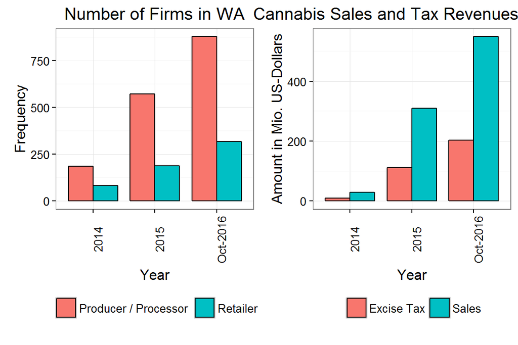

Business Development of Cannabis Production and Sales in Washington State

As we can see from Figure 1, the nascent industry is already booming in Washington with both the numbers of actors and the sales/tax revenues being already higher in October 2016 than in all of 2015. The numbers are quite staggering:

1. Number of Producers and Processors: The number increased by 210% YoY in 2015 from 185 to 574 and by another 53% in the ten months leading up to October 2016 to 881.
2. Number of Retailers: The number increased by 130% YoY in 2015 from 82 to 189 and by another 69% in the ten months leading up to October 2016 to 319.
3. Increase of revenues in sales: The number increased by 960% YoY in 2015 from $29.21[^8] Mill to $309.86 Mill and by another 77% in the ten months leading up to October 2016 to $549.93 Mill.
4. Increase of tax revenues: The number increased by 1040% YoY in 2015 from $9.74 Mill to $110.97 Mill and by another 83% in the ten months leading up to October 2016 to $203.47 Mill.

It is a fast growing industry, and shows increasing interest of buyers. In relation to Washington State’s GDP it is, however, still relatively small with a share of 0.12 % of a GDP of [$445.4 Bill](https://www.bea.gov/regional/bearfacts/pdf.cfm?fips=53000&areatype=STATE&geotype=3).[^9] Unfortunately, we do not have data on the quantities that have been sold or reliable data on the price development of the good. In either of these scenarios we could have otherwise also analysed the usage.

Table 1 shows the variables used in the next part of our analysis. While Seattle is divided into 132 districts by the U.S. Census, crime incidents only occured in 35 of them once accounting for other NA-related issues with our merged data set. Eight of these 35 districts have a dispensary, which is represented by the *treatment* variable “Established”. The dependent variable is the natural logarithm of crime incidents per 1000 inhabitants.[^10] The poverty rate, age, diversity and education are socio-economic control variables. Table 1 also indicates how these variables have been operationalised.

\begin{table}[ht] \centering \begin{tabular}{rll} \hline & Variables & Operationalisation \\ \hline 1 & Producer/Processor & Count of Producers/Processors in WA \\ 2 & Retailer & Count of Retailers in WA \\ 3 & Excise Tax & Sum of taxes paid by retailers \\ 4 & Sales & Sum of revenue made by retailers \\ 5 & Crime Categories & Aggregates of Crime incidents from Seattle 911-Incident Database in log/1000 citizens \\ 6 & Established & Treatment variable: 0 if no dispensary, 1 otherwise \\ 7 & Poverty Rate & Share of People $<$ \$15,000/year as percent of total people in district \\ 8 & Age & Shares of Adults in comparison to mean of Seattle \\ 9 & Diversity & Share of Whites in comparison to mean of Seattle \\ 10 & Education & Share of Degree holders in comparison to mean of Seattle \\ 11 & GEOID & U.S. Census District \\ 12 & Time & Months from Jan 2014 to Oct 2016 \\ \hline \end{tabular} \caption{List of dependent and explanatory variables used in analysis} \end{table}

[figure not shown]

Map of Crime incidents in Seattle in October 2016

If we look at crime incidents per 1,000 citizens in Figure 3 in the Appendix, then we can see that the development has been different between the different categories. As you can see from Figure 4 in the Appendix, however, only looking at the distribution, however, might be a problem due to the heavy right-tail skew. Thus, and in order to make interpretation easier, we will take the natural logarithm. Figure 4 in the Appendix now shows a slightly different picture where most of the crime follows a random walk, i.e. there is change in either direction without there being a trend. Only burglary/theft, property, and violent crime seems to have an upward trend, while other drug related crimes seem to have dropped recently.

We tested if the our analysis might be skewed due to the jumps from January 2014 to February 2014 that we can see in the Figures in the Appendix. The jumps might be due to coding changes/errors from one year to the next. We have not found any statistical significance. You can find the results in first table of the Appendix.

### Inferential Statistics

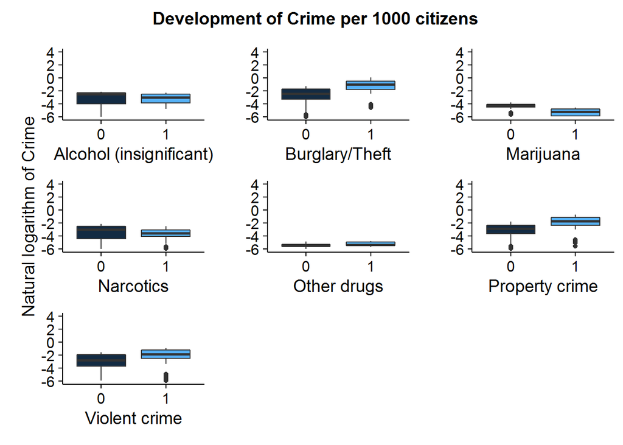

Impact of Dispensaries on Crime incident - Mean-difference

Yet, a simple differences in means analysis does not do our question justice. So we are looking at a regression.

\begin{table}[!htbp] \centering \caption{Analysis of Crime} \label{} \begin{tabular}{@{\extracolsep{5pt}}lcc} \\[-1.8ex]\hline \hline \\[-1.8ex] & \multicolumn{2}{c}{\textit{Dependent variable:}} \\ \cline{2-3} \\[-1.8ex] & \multicolumn{2}{c}{ln(Crime Rate Per Thousand)} \\ & OLS Simple & Propensity Simple \\ \\[-1.8ex] & (1) & (2)\\ \hline \\[-1.8ex] Established & 1.34$^{***}$ (1.33, 1.35) & 0.55$^{***}$ (0.54, 0.57) \\ Constant & $-$2.98$^{***}$ ($-$2.98, $-$2.97) & $-$2.98$^{***}$ ($-$2.98, $-$2.97) \\ \hline \\[-1.8ex] Observations & 228,574 & 208,172 \\ R$^{2}$ & 0.17 & 0.02 \\ Adjusted R$^{2}$ & 0.17 & 0.02 \\ Residual Std. Error & 1.20 (df = 228572) & 1.16 (df = 208170) \\ F Statistic & 46,214.14$^{***}$ (df = 1; 228572) & 5,178.47$^{***}$ (df = 1; 208170) \\ \hline \hline \\[-1.8ex] \textit{Note:} & \multicolumn{2}{r}{$^{*}$p$<$0.1; $^{**}$p$<$0.05; $^{***}$p$<$0.01} \\ \end{tabular} \end{table}

\begin{table}[!htbp] \centering \caption{Analysis of Crime} \label{} \begin{tabular}{@{\extracolsep{5pt}}lcc} \\[-1.8ex]\hline \hline \\[-1.8ex] & \multicolumn{2}{c}{\textit{Dependent variable:}} \\ \cline{2-3} \\[-1.8ex] & \multicolumn{2}{c}{ln(Crime Rate Per Thousand)} \\ & OLS Full & Propensity Full \\ \\[-1.8ex] & (1) & (2)\\ \hline \\[-1.8ex] Established & 1.40$^{***}$ (1.39, 1.42) & 0.66$^{***}$ (0.65, 0.67) \\ share\_poverty & 0.04$^{***}$ (0.04, 0.04) & 0.05$^{***}$ (0.05, 0.05) \\ Adulthood\# Adults: Above average & $-$0.11$^{***}$ ($-$0.13, $-$0.09) & $-$1.21$^{***}$ ($-$1.24, $-$1.19) \\ Adulthood\# Adults: Below average & 1.10$^{***}$ (1.08, 1.12) & 0.35$^{***}$ (0.34, 0.36) \\ Adulthood\# Adults: Just above average & 0.24$^{***}$ (0.22, 0.26) & $-$0.52$^{***}$ ($-$0.53, $-$0.51) \\ EduCat\# Graduates: High & 0.02 ($-$0.01, 0.05) & $-$1.33$^{***}$ ($-$1.37, $-$1.29) \\ EduCat\# Graduates: Very High & $-$0.79$^{***}$ ($-$0.83, $-$0.76) & $-$2.42$^{***}$ ($-$2.47, $-$2.38) \\ EduCat\# Graduates: Very low & $-$1.29$^{***}$ ($-$1.33, $-$1.26) & $-$2.42$^{***}$ ($-$2.47, $-$2.38) \\ DiversityDiversity: High & 0.17$^{***}$ (0.15, 0.19) & 0.11$^{***}$ (0.10, 0.12) \\ DiversityDiversity: Very high & 0.06$^{***}$ (0.04, 0.08) & $-$0.23$^{***}$ ($-$0.26, $-$0.21) \\ DiversityDiversity: Very Low & 0.40$^{***}$ (0.37, 0.43) & 1.03$^{***}$ (1.01, 1.05) \\ Constant & $-$3.51$^{***}$ ($-$3.54, $-$3.48) & $-$1.22$^{***}$ ($-$1.25, $-$1.18) \\ \hline \\[-1.8ex] Observations & 228,574 & 175,643 \\ R$^{2}$ & 0.33 & 0.53 \\ Adjusted R$^{2}$ & 0.33 & 0.53 \\ Residual Std. Error & 1.07 (df = 228562) & 0.53 (df = 175631) \\ F Statistic & 10,319.37$^{***}$ (df = 11; 228562) & 18,020.97$^{***}$ (df = 11; 175631) \\ \hline \hline \\[-1.8ex] \textit{Note:} & \multicolumn{2}{r}{$^{*}$p$<$0.1; $^{**}$p$<$0.05; $^{***}$p$<$0.01} \\ \end{tabular} \end{table}

\begin{table}[!htbp] \centering \caption{Analysis of Crime} \label{} \begin{tabular}{@{\extracolsep{5pt}}lc} \\[-1.8ex]\hline \hline \\[-1.8ex] & \multicolumn{1}{c}{\textit{Dependent variable:}} \\ \cline{2-2} \\[-1.8ex] & ln(Crime Rate Per Thousand) \\ & Fixed Effects \\ \hline \\[-1.8ex] Established & 0.59$^{***}$ (0.58, 0.61) \\ \hline \\[-1.8ex] Observations & 228,574 \\ R$^{2}$ & 0.02 \\ Adjusted R$^{2}$ & 0.02 \\ F Statistic & 4,178.01$^{***}$ (df = 1; 228538) \\ \hline \hline \\[-1.8ex] \textit{Note:} & \multicolumn{1}{r}{$^{*}$p$<$0.1; $^{**}$p$<$0.05; $^{***}$p$<$0.01} \\ \end{tabular} \end{table}

## Appendix

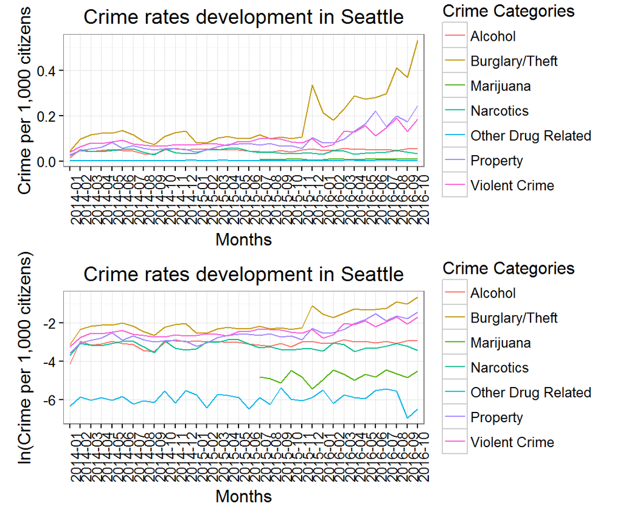

A.1 - Development of Crime in Seattle

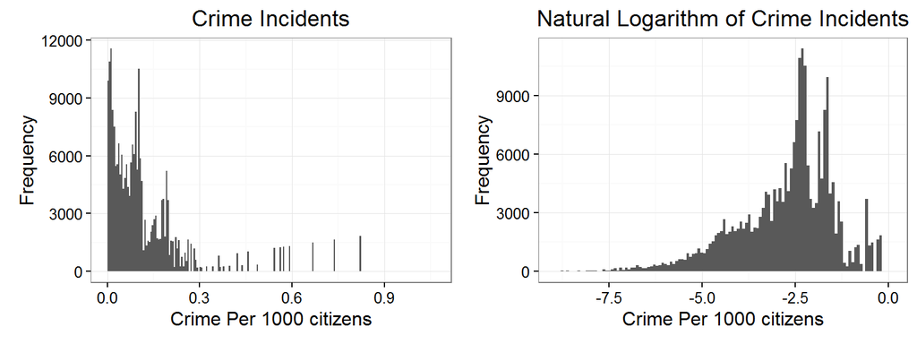

A.2 - Distribution of Crime across the Districts

\begin{table}[!htbp] \centering \caption{Analysis of Crime} \label{} \begin{tabular}{@{\extracolsep{5pt}}lcc} \\[-1.8ex]\hline \hline \\[-1.8ex] & \multicolumn{2}{c}{\textit{Dependent variable:}} \\ \cline{2-3} \\[-1.8ex] & \multicolumn{2}{c}{ln(Crime Rate Per Thousand)} \\ & Full Model & Without Jan 2014 \\ \\[-1.8ex] & (1) & (2)\\ \hline \\[-1.8ex] Established & 1.34$^{***}$ (1.33, 1.35) & 1.33$^{***}$ (1.32, 1.34) \\ Constant & $-$2.98$^{***}$ ($-$2.98, $-$2.97) & $-$2.97$^{***}$ ($-$2.97, $-$2.96) \\ \hline \\[-1.8ex] Observations & 228,574 & 226,147 \\ R$^{2}$ & 0.17 & 0.17 \\ Adjusted R$^{2}$ & 0.17 & 0.17 \\ \hline \hline \\[-1.8ex] \textit{Note:} & \multicolumn{2}{r}{$^{*}$p$<$0.1; $^{**}$p$<$0.05; $^{***}$p$<$0.01} \\ \end{tabular} \end{table}

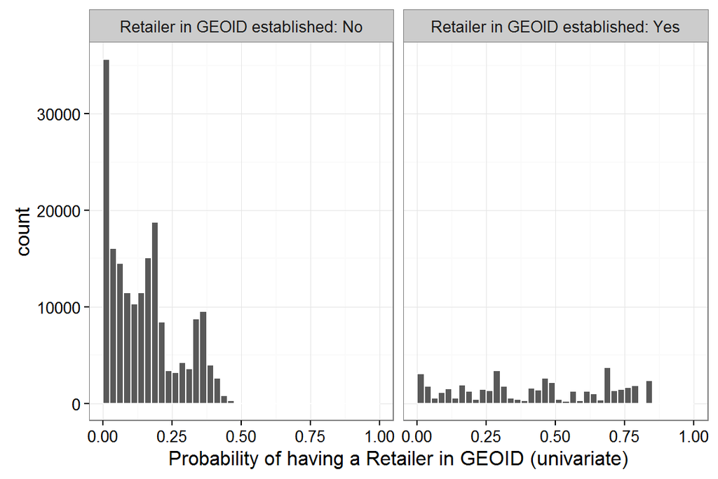

A.5 - Common Support Graph/Visualisation propensity score matching

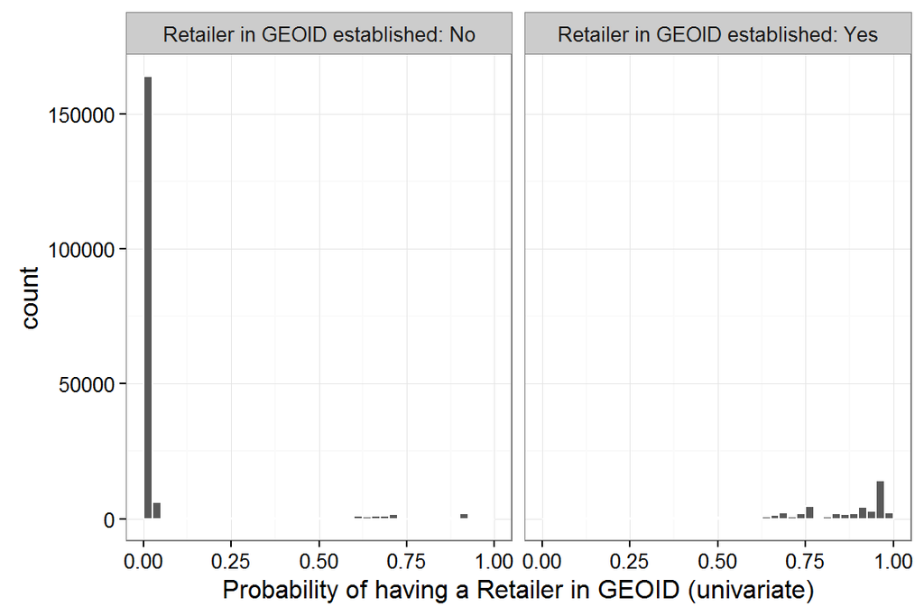

A.6 - Common Support Graph/Visualisation propensity score matching with covariates

## References

Bache, Stefan Milton, and Hadley Wickham. 2014. *Magrittr: A Forward-Pipe Operator for R*. https://CRAN.R-project.org/package=magrittr.

Bivand, Roger, and Nicholas Lewin-Koh. 2016. *Maptools: Tools for Reading and Handling Spatial Objects*. https://CRAN.R-project.org/package=maptools.

Bivand, Roger, Tim Keitt, and Barry Rowlingson. 2016. *Rgdal: Bindings for the Geospatial Data Abstraction Library*. https://CRAN.R-project.org/package=rgdal.

Caulkins, Jonathan P, Beau Kilmer, Mark AR Kleiman, Robert J MacCoun, Gregory Midgette, Pat Oglesby, Rosalie Liccardo Pacula, and Peter H Reuter. 2015. “Options and Issues Regarding Marijuana Legalization.” *Santa Monica, CA: The RAND Corporation Retrieved from Http://www. Rand. Org/content/dam/rand/pubs/perspectives/PE100/PE149/RAND_PE149. Pdf (Archived by WebCite at Http://www. Webcitation. Org/6Z3moG28A)*.

Croissant, Yves, Giovanni Millo, and Kevin Tappe. 2016. *Plm: Linear Models for Panel Data*. https://CRAN.R-project.org/package=plm.

Dills, Angela, Sietse Goffard, and Jeffrey Miron. 2016. “Dose of Reality: The Effect of State Marijuana Legalizations.”

Glenn, Ezra Haber. 2016. *Acs: Download, Manipulate, and Present American Community Survey and Decennial Data from the US Census*. https://CRAN.R-project.org/package=acs.

Harrison, John. 2016. *RSelenium: R Bindings for Selenium WebDriver*. https://CRAN.R-project.org/package=RSelenium.

Möhring, Katja. 2012. “The Fixed Effect as an Alternative to Multilevel Analysis for Cross-National Analyses.” *Cologne: University of Cologne (GK Soclife Working Paper 16)*.

Nychka, Douglas, Reinhard Furrer, John Paige, and Stephan Sain. 2016. *Fields: Tools for Spatial Data*. https://CRAN.R-project.org/package=fields.

Ooms, Jeroen, Duncan Temple Lang, and Lloyd Hilaiel. 2016. *Jsonlite: A Robust, High Performance JSON Parser and Generator for R*. https://CRAN.R-project.org/package=jsonlite.

Pebesma, Edzer, and Roger Bivand. 2016. *Sp: Classes and Methods for Spatial Data*. https://CRAN.R-project.org/package=sp.

Temple Lang, Duncan. 2014. *RJSONIO: Serialize R Objects to JSON, JavaScript Object Notation*. https://CRAN.R-project.org/package=RJSONIO.

Temple Lang, Duncan, and the CRAN team. 2016. *RCurl: General Network (HTTP/FTP/.) Client Interface for R*. https://CRAN.R-project.org/package=RCurl.

Walker, Kyle. 2016. *Tigris: Load Census TIGER/Line Shapefiles into R*. https://CRAN.R-project.org/package=tigris.

Warnes, Gregory R., Ben Bolker, Gregor Gorjanc, Gabor Grothendieck, Ales Korosec, Thomas Lumley, Don MacQueen, Arni Magnusson, Jim Rogers, and others. 2015. *Gdata: Various R Programming Tools for Data Manipulation*. https://CRAN.R-project.org/package=gdata.

Wickham, Hadley. 2016a. *Rvest: Easily Harvest (Scrape) Web Pages*. https://CRAN.R-project.org/package=rvest.

———. 2016b. *Scales: Scale Functions for Visualization*. https://CRAN.R-project.org/package=scales.

Wickham, Hadley, and Romain Francois. 2016. *Dplyr: A Grammar of Data Manipulation*. https://CRAN.R-project.org/package=dplyr.